# Integrantes do Projeto

Este projeto foi desenvolvido pelos seguintes alunos do módulo V - Machine Learning I, do curso de Data Science da escola Ada Tech, em parceria com o projeto Santander Coders:

- Laura Campos
- Guilherme Araujo
- Guilherme de Almeida
- Carlos Eduardo
- Luiz Henrique

## Curso e Parceria

O curso é ministrado pelo professor Tiago Marto, que guiou os alunos através do processo de aprendizado prático e teórico necessário para o desenvolvimento deste projeto. A parceria entre a Ada Tech e o Santander Coders visa fornecer uma formação prática e voltada para a indústria, preparando os alunos para enfrentar desafios reais do mundo dos dados.

## Objetivo do Curso

O curso tem como objetivo desenvolver competências técnicas em Data Science, permitindo que os alunos apliquem técnicas de machine learning e análise de dados em problemas reais, como é o caso deste projeto de detecção de fraudes em transações de e-commerce.

# Detecção de Fraudes em Transações de E-commerce

## Contexto

No ambiente digital atual, o e-commerce tem crescido exponencialmente, o que consequentemente aumenta o volume de transações financeiras online. Com esse aumento, surge também uma maior incidência de atividades fraudulentas, representando um grande desafio para empresas e consumidores. A detecção eficaz de fraudes é crucial para minimizar perdas financeiras e manter a confiança do consumidor.

## Descrição do Dataset

Este projeto utiliza um dataset sintético denominado ["Fraudulent E-Commerce Transactions"](https://www.kaggle.com/datasets/shriyashjagtap/fraudulent-e-commerce-transactions), que foi criado especificamente para simular dados de transações de uma plataforma de e-commerce com foco na detecção de fraudes. O dataset contém características comuns encontradas em dados transacionais, além de atributos especificamente projetados para apoiar o desenvolvimento e teste de algoritmos de detecção de fraudes.

### Visão Geral do Dataset

- **Número de Transações**: 1,472,952 (Versão 1) e 23,634 (Versão 2)
- **Características**: 16
- **Transações Fraudulentas**: Aproximadamente 5%

### Detalhes das Variáveis

- **Transaction ID**: Identificador único de cada transação.
- **Customer ID**: Identificador único de cada cliente.
- **Transaction Amount**: Valor total da transação.
- **Transaction Date**: Data e hora da transação.
- **Payment Method**: Método de pagamento utilizado.
- **Product Category**: Categoria do produto envolvido na transação.
- **Quantity**: Número de produtos envolvidos na transação.
- **Customer Age**: Idade do cliente.
- **Customer Location**: Localização geográfica do cliente.
- **Device Used**: Tipo de dispositivo usado para realizar a transação.
- **IP Address**: Endereço IP do dispositivo utilizado.
- **Shipping Address**: Endereço de envio do produto.
- **Billing Address**: Endereço de faturamento.
- **Is Fraudulent**: Indicador binário de fraude na transação.
- **Account Age Days**: Idade da conta do cliente em dias no momento da transação.
- **Transaction Hour**: Hora do dia em que a transação ocorreu.

## Objetivo do Projeto

Desenvolver um modelo de machine learning capaz de identificar transações fraudulentas em dados de e-commerce. Este modelo busca não apenas minimizar o impacto financeiro das fraudes mas também servir como uma ferramenta de segurança para melhorar a experiência do usuário e a confiabilidade do sistema de transações online.

## Estrutura do Projeto

Este notebook seguirá os seguintes passos para abordar o problema de detecção de fraudes:

1. Análise Exploratória de Dados (EDA) para entender as características e a distribuição das transações.
2. Pré-processamento e limpeza dos dados.
3. Comparação de diferentes modelos de machine learning para identificar o mais eficaz na detecção de fraudes.
4. Otimização de hiperparâmetros para melhorar o desempenho dos modelos.
5. Avaliação dos modelos usando métricas específicas para determinar a adequação do modelo final.

A partir daqui, o notebook procederá com a carga e análise dos dados, seguido pelo desenvolvimento e avaliação dos modelos de machine learning.

# Carregamento dos dados e Análise Exploratória de dados

```python
import pandas as pd
import numpy as np
import seaborn as sns
from sklearn.model_selection import train_test_split, GridSearchCV, KFold, StratifiedKFold, RandomizedSearchCV
from sklearn.ensemble import AdaBoostClassifier, RandomForestClassifier
from sklearn.preprocessing import StandardScaler
from sklearn.tree import DecisionTreeClassifier
from imblearn.over_sampling import SMOTE, BorderlineSMOTE
from imblearn.pipeline import Pipeline as ImPipeline
from sklearn.metrics import recall_score, f1_score, make_scorer
import matplotlib.pyplot as plt
from sklearn.metrics import confusion_matrix, ConfusionMatrixDisplay
from sklearn.metrics import classification_report
from scipy.stats import randint, uniform
from scipy.stats import zscore
```

```python
from google.colab import drive
drive.mount('/content/drive')
```

```python
# df = pd.read_csv('/content/drive/MyDrive/Colab Notebooks/Fraudulent_E-Commerce_Transaction_Data_2.csv')
df = pd.read_csv('C:\Workspace\CURSO ADA TECH\MODULO V - Machine Learning I\projeto\Fraudulent_E-Commerce_Transaction_Data.csv')
```

```python
df['Transaction Date'].max()
```

```
'2024-04-03 08:13:56'
```

## Análises Iniciais

Primeiro exploramos os dados como um todo para verificar se existia algum tipo de problema com o dataset, como dados nulos, dados inconsistentes e outliers. Observamos as variáveis, os seus tipos, distribuições e correlações.

```python
df.head()
```

|  | Transaction ID | Customer ID | Transaction Amount | Transaction Date | Payment Method | Product Category | Quantity | Customer Age | Customer Location | Device Used | IP Address | Shipping Address | Billing Address | Is Fraudulent | Account Age Days | Transaction Hour |
| --- | --- | --- | --- | --- | --- | --- | --- | --- | --- | --- | --- | --- | --- | --- | --- | --- |
| 0 | c12e07a0-8a06-4c0d-b5cc-04f3af688570 | 8ca9f102-02a4-4207-ab63-484e83a1bdf0 | 42.32 | 2024-03-24 23:42:43 | PayPal | electronics | 1 | 40 | East Jameshaven | desktop | 110.87.246.85 | 5399 Rachel Stravenue Suite 718\nNorth Blakebu... | 5399 Rachel Stravenue Suite 718\nNorth Blakebu... | 0 | 282 | 23 |
| 1 | 7d187603-7961-4fce-9827-9698e2b6a201 | 4d158416-caae-4b09-bd5b-15235deb9129 | 301.34 | 2024-01-22 00:53:31 | credit card | electronics | 3 | 35 | Kingstad | tablet | 14.73.104.153 | 5230 Stephanie Forge\nCollinsbury, PR 81853 | 5230 Stephanie Forge\nCollinsbury, PR 81853 | 0 | 223 | 0 |
| 2 | f2c14f9d-92df-4aaf-8931-ceaf4e63ed72 | ccae47b8-75c7-4f5a-aa9e-957deced2137 | 340.32 | 2024-01-22 08:06:03 | debit card | toys & games | 5 | 29 | North Ryan | desktop | 67.58.94.93 | 195 Cole Oval\nPort Larry, IA 58422 | 4772 David Stravenue Apt. 447\nVelasquezside, ... | 0 | 360 | 8 |
| 3 | e9949bfa-194d-486b-84da-9565fca9e5ce | b04960c0-aeee-4907-b1cd-4819016adcef | 95.77 | 2024-01-16 20:34:53 | credit card | electronics | 5 | 45 | Kaylaville | mobile | 202.122.126.216 | 7609 Cynthia Square\nWest Brenda, NV 23016 | 7609 Cynthia Square\nWest Brenda, NV 23016 | 0 | 325 | 20 |
| 4 | 7362837c-7538-434e-8731-0df713f5f26d | de9d6351-b3a7-4bc7-9a55-8f013eb66928 | 77.45 | 2024-01-16 15:47:23 | credit card | clothing | 5 | 42 | North Edwardborough | desktop | 96.77.232.76 | 2494 Robert Ramp Suite 313\nRobinsonport, AS 5... | 2494 Robert Ramp Suite 313\nRobinsonport, AS 5... | 0 | 116 | 15 |

```python
df.describe()
```

|  | Transaction Amount | Quantity | Customer Age | Is Fraudulent | Account Age Days | Transaction Hour |
| --- | --- | --- | --- | --- | --- | --- |
| count | 23634.000000 | 23634.000000 | 23634.000000 | 23634.000000 | 23634.000000 | 23634.000000 |
| mean | 229.367099 | 3.000550 | 34.560210 | 0.051705 | 178.660531 | 11.266015 |
| std | 282.046669 | 1.419663 | 10.009471 | 0.221436 | 107.388682 | 6.980659 |
| min | 10.000000 | 1.000000 | -2.000000 | 0.000000 | 1.000000 | 0.000000 |
| 25% | 69.070000 | 2.000000 | 28.000000 | 0.000000 | 84.000000 | 5.000000 |
| 50% | 151.415000 | 3.000000 | 35.000000 | 0.000000 | 178.000000 | 11.000000 |
| 75% | 296.127500 | 4.000000 | 41.000000 | 0.000000 | 272.000000 | 17.000000 |
| max | 9716.500000 | 5.000000 | 73.000000 | 1.000000 | 365.000000 | 23.000000 |

```python
df[(df['Customer Age'] < 0)].groupby('Is Fraudulent')['Customer Age'].count()
```

```
Is Fraudulent
0    1
Name: Customer Age, dtype: int64
```

```python
df.info()
```

```
<class 'pandas.core.frame.DataFrame'>
RangeIndex: 23634 entries, 0 to 23633
Data columns (total 16 columns):
 #   Column              Non-Null Count  Dtype
---  ------              --------------  -----
 0   Transaction ID      23634 non-null  object
 1   Customer ID         23634 non-null  object
 2   Transaction Amount  23634 non-null  float64
 3   Transaction Date    23634 non-null  object
 4   Payment Method      23634 non-null  object
 5   Product Category    23634 non-null  object
 6   Quantity            23634 non-null  int64
 7   Customer Age        23634 non-null  int64
 8   Customer Location   23634 non-null  object
 9   Device Used         23634 non-null  object
 10  IP Address          23634 non-null  object
 11  Shipping Address    23634 non-null  object
 12  Billing Address     23634 non-null  object
 13  Is Fraudulent       23634 non-null  int64
 14  Account Age Days    23634 non-null  int64
 15  Transaction Hour    23634 non-null  int64
dtypes: float64(1), int64(5), object(10)
memory usage: 2.9+ MB
```

```python
numeric_columns = df.select_dtypes(include=['int64', 'float64'])
correlation_matrix = numeric_columns.corr()
correlation_matrix
```

|  | Transaction Amount | Quantity | Customer Age | Is Fraudulent | Account Age Days | Transaction Hour |
| --- | --- | --- | --- | --- | --- | --- |
| Transaction Amount | 1.000000 | 0.008426 | -0.008015 | 0.275459 | -0.044580 | -0.028962 |
| Quantity | 0.008426 | 1.000000 | -0.000445 | -0.005340 | -0.004549 | 0.004059 |
| Customer Age | -0.008015 | -0.000445 | 1.000000 | 0.004819 | -0.012201 | 0.003518 |
| Is Fraudulent | 0.275459 | -0.005340 | 0.004819 | 1.000000 | -0.142467 | -0.122226 |
| Account Age Days | -0.044580 | -0.004549 | -0.012201 | -0.142467 | 1.000000 | 0.024355 |
| Transaction Hour | -0.028962 | 0.004059 | 0.003518 | -0.122226 | 0.024355 | 1.000000 |

```python
df['Is Fraudulent'].value_counts(normalize=True)
```

```
Is Fraudulent
0    0.948295
1    0.051705
Name: proportion, dtype: float64
```

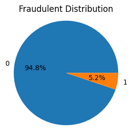

```python
plt.figure(figsize=(3, 3))
plt.pie(df['Is Fraudulent'].value_counts(), labels=df['Is Fraudulent'].unique(), autopct='%1.1f%%')
plt.title('Fraudulent Distribution')
plt.axis('equal')
plt.show()
```

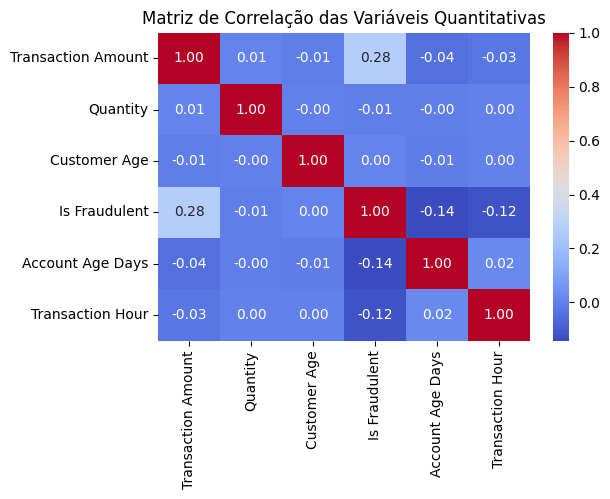

```python
plt.figure(figsize=(6, 4))
sns.heatmap(correlation_matrix, annot=True, fmt=".2f", cmap='coolwarm')
plt.title('Matriz de Correlação das Variáveis Quantitativas')
plt.show()
```

**Conclusões**:

- A base é extremamente desbalanceada
- As variáveis possuem ordens de grandeza distintas
- A variável idade possue valores negativos
- Ausência de valores nulos
- As variáveis quantitativas possuem uma baixa correlação entre si

Pensando nessas conclusões, teremos que fazer tratamentos de balanceamento, escalonamento e exclusão de valores negativos.

## Análises de distribuição

**Distribuição de Características Individuais**

- **Histogramas** ou **gráficos de densidade** para variáveis contínuas como `Transaction Amount`, `Customer Age`, `Account Age Days`:

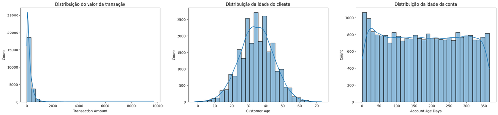

```python
plt.subplots(1, 3, figsize=(25, 5))

plt.subplot(1, 3, 1)
sns.histplot(df['Transaction Amount'], bins=30, kde=True)
plt.title('Distribuição do valor da transação')

plt.subplot(1, 3, 2)
sns.histplot(df['Customer Age'], bins=30, kde=True)
plt.title('Distribuição da idade do cliente')

plt.subplot(1, 3, 3)
sns.histplot(df['Account Age Days'], bins=30, kde=True)
plt.title('Distribuição da idade da conta')

plt.show()
```

**Conclusões:**

- A maior parte dos valores de transação se encontram entre 0 e 2000
- A idade do cleinte apresenta uma distribuição aparentemente normal
- Existe um pico de registros em contas mais recentes, mas a distribuição aparerenta ser bem homogênea.

**Gráficos de barras** para variáveis categóricas como `Payment Method`, `Product Category`, `Device Used`:

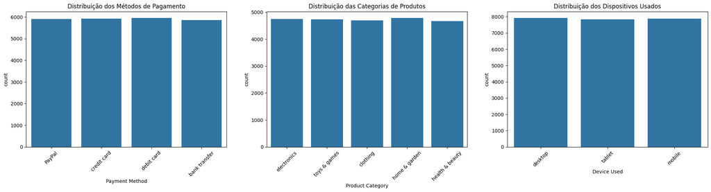

```python
plt.subplots(1, 3, figsize=(25, 5))

plt.subplot(1, 3, 1)
sns.countplot(x='Payment Method', data=df)
plt.title('Distribuição dos Métodos de Pagamento')
plt.xticks(rotation=45)

plt.subplot(1, 3, 2)
sns.countplot(x='Product Category', data=df)
plt.title('Distribuição das Categorias de Produtos')
plt.xticks(rotation=45)

plt.subplot(1, 3, 3)
sns.countplot(x='Device Used', data=df)
plt.title('Distribuição dos Dispositivos Usados')
plt.xticks(rotation=45)

plt.show()
```

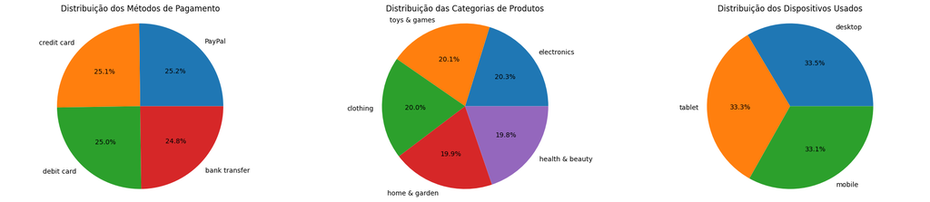

```python
plt.subplots(1, 3, figsize=(25, 5))

plt.subplot(1, 3, 1)
plt.pie(df['Payment Method'].value_counts(), labels=df['Payment Method'].unique(), autopct='%1.1f%%')
plt.title('Distribuição dos Métodos de Pagamento')
plt.axis('equal')

plt.subplot(1, 3, 2)
plt.pie(df['Product Category'].value_counts(), labels=df['Product Category'].unique(), autopct='%1.1f%%')
plt.title('Distribuição das Categorias de Produtos')
plt.axis('equal')

plt.subplot(1, 3, 3)
plt.pie(df['Device Used'].value_counts(), labels=df['Device Used'].unique(), autopct='%1.1f%%')
plt.title('Distribuição dos Dispositivos Usados')
plt.axis('equal')

plt.show()
```

**Conclusões:**

- As variáveis categóricas estão super bem distribuídas, ou seja, existe quase a mesma quantidade de registros dentro de cada categoria. Isso provavlemente se deve ao fato de que a base foi gerada de forma sintética.

**Relação Entre Características e Classe Alvo**

- **Boxplots** para visualizar a relação entre variáveis numéricas e o indicador de fraude:

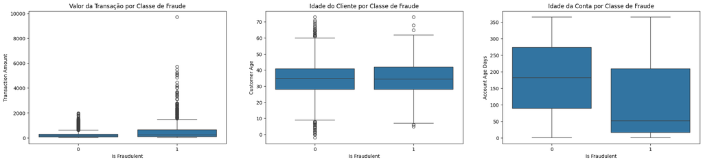

```python
plt.subplots(1, 3, figsize=(25, 5))

plt.subplot(1, 3, 1)
sns.boxplot(x='Is Fraudulent', y='Transaction Amount', data=df)
plt.title('Valor da Transação por Classe de Fraude')

plt.subplot(1, 3, 2)
sns.boxplot(x='Is Fraudulent', y='Customer Age', data=df)
plt.title('Idade do Cliente por Classe de Fraude')

plt.subplot(1, 3, 3)
sns.boxplot(x='Is Fraudulent', y='Account Age Days', data=df)
plt.title('Idade da Conta por Classe de Fraude')

plt.show()
```

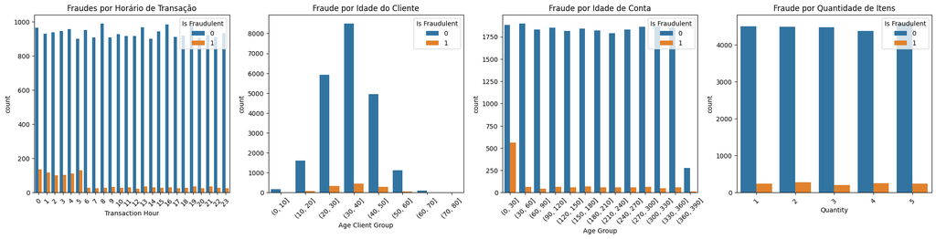

```python
plt.subplots(1, 4, figsize=(25, 5))

plt.subplot(1, 4, 1)
sns.countplot(x="Transaction Hour", data=df, hue='Is Fraudulent')
plt.title('Fraudes por Horário de Transação')
plt.xticks(rotation=45)

plt.subplot(1, 4, 2)
delta_x1 = 10
df['Age Client Group'] = pd.cut(df['Customer Age'], bins=range(0, df['Customer Age'].max() + delta_x1, delta_x1))
df['Age Client Group'] = pd.Categorical(df['Age Client Group'])
sns.countplot(x='Age Client Group', hue='Is Fraudulent', data=df)
plt.title('Fraude por Idade do Cliente')
plt.xticks(rotation=45)

plt.subplot(1, 4, 3)
delta_x2 = 30
df['Age Group'] = pd.cut(df['Account Age Days'], bins=range(0, df['Account Age Days'].max() + delta_x2, delta_x2))
df['Age Group'] = pd.Categorical(df['Age Group'])
sns.countplot(x='Age Group', hue='Is Fraudulent', data=df)
plt.title('Fraude por Idade de Conta')
plt.xticks(rotation=45)

plt.subplot(1, 4, 4)
sns.countplot(x="Quantity", data=df, hue='Is Fraudulent')
plt.title('Fraude por Quantidade de Itens')
plt.xticks(rotation=45)

plt.show()
```

**Conclusões:**

- A ocorrência de fraude dentro das variáveis de idade do cliente e quantidade de itens estão bem distribuídas, ou seja, a proporção entre registros com fraudes e sem fraudes se mantém para todas as categorias.
- A ocorrência de fraude aparenta ocorrer com mais frequência na madrugada (entre 0h e 5h)
- A ocorrência de fraude aparenta ocorrer com mais frequência em contas masi recentes (menos de 30 dias de idade)

**Gráficos de barras empilhadas** ou **count plots segmentados** para explorar relações entre características categóricas e fraudes:

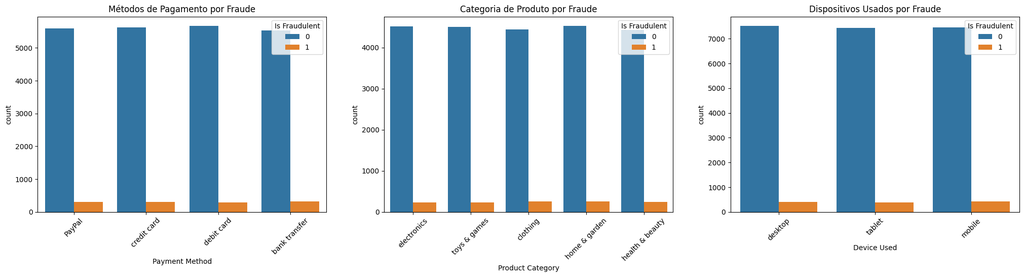

```python
plt.subplots(1, 3, figsize=(25, 5))

plt.subplot(1, 3, 1)
sns.countplot(x='Payment Method', hue='Is Fraudulent', data=df)
plt.title('Métodos de Pagamento por Fraude')
plt.xticks(rotation=45)

plt.subplot(1, 3, 2)
sns.countplot(x='Product Category', hue='Is Fraudulent', data=df)
plt.title('Categoria de Produto por Fraude')
plt.xticks(rotation=45)

plt.subplot(1, 3, 3)
sns.countplot(x='Device Used', hue='Is Fraudulent', data=df)
plt.title('Dispositivos Usados por Fraude')
plt.xticks(rotation=45)

plt.show()
```

**Conclusões:**

- A ocorrência de fraude dentro das variáveis categóricas estão bem distribuídas, ou seja, a proporção entre registros com fraudes e sem fraudes se mantém para todas as categorias.